# R Notebook

```r
setwd("C:/Users/Architect_shwet/Desktop/social cops")
```

```r
library(anytime)
library(dplyr)
library(data.table)
library(readr)
library("tibble")
library(lubridate)
library(ggplot2)
library(tidyr)
library(plyr)
library(highcharter)
library(ggExtra)
library(gridExtra)
```

```r
monthly <- read.csv('Monthly_data_cmo.csv')
cmo <- read.csv('CMO_MSP_Mandi.csv')
```

# Creating a year month variable and converting it to a datetime object

```r
monthly$day <- '-01'
monthly$date_plus <- paste(monthly$date, monthly$day)
monthly$date_plus <- gsub(' ', '', monthly$date_plus)
monthly$date_plus <- ymd(monthly$date_plus)
monthly$day <- NULL
monthly$date <- NULL
```

# Removing the variables which has one unique value

```r
monthly$state_name <- NULL
```

# Total number of commodies for each month

```r
monthly %>%
  group_by(Month) %>%
  tally() %>%
  arrange(n)
```

| Month | n |
| --- | --- |
| April | 4445 |
| July | 4498 |
| March | 4528 |
| August | 4554 |
| May | 4611 |
| February | 4625 |
| December | 4816 |
| January | 4858 |
| June | 4906 |
| September | 6518 |

[output cut: 2 more lines]

# For each district, I have calculated mean, median of modal price, min price, max price and arrivals in qtl

```r
ddply(monthly,~district_name,summarise,
      meanmodalprice=mean(modal_price, na.rm =T), median_modalprice = median(modal_price, na.rm = T),
      mean_minprice = mean(min_price, na.rm = T), median_minprice = median(min_price, na.rm = T),
      mean_maxprice = mean(max_price, na.rm = T), median_maxprice = median(max_price, na.rm = T),
      mean_quantity = mean(arrivals_in_qtl, na.rm = T), median_quantity = median(arrivals_in_qtl, na.rm = T))
```

[output not shown]

[output cut: 23 more lines]

# Similarly, for each date, I have calculated mean, median of modal price, min price, max price and arrivals in qtl

```r
ddply(monthly,~date_plus,summarise,
      meanmodalprice=mean(modal_price, na.rm =T), median_modalprice = median(modal_price, na.rm = T),
      mean_minprice = mean(min_price, na.rm = T), median_minprice = median(min_price, na.rm = T),
      mean_maxprice = mean(max_price, na.rm = T), median_maxprice = median(max_price, na.rm = T),
      mean_quantity = mean(arrivals_in_qtl, na.rm = T), median_quantity = median(arrivals_in_qtl, na.rm = T))
```

| date_plus | meanmodalprice | median_modalprice | mean_minprice | median_minprice | mean_maxprice | median_maxprice | mean_quantity | median_quantity |
| --- | --- | --- | --- | --- | --- | --- | --- | --- |
| 2014-09-01 | 2949.621 | 2301.0 | 2563.981 | 1920.0 | 3341.561 | 2617.0 | 5113.923 | 184.0 |
| 2014-10-01 | 2963.269 | 2300.0 | 2605.260 | 1970.0 | 3328.379 | 2586.5 | 4340.577 | 180.5 |
| 2014-11-01 | 3088.639 | 2517.0 | 2745.371 | 2153.0 | 3460.061 | 2850.0 | 6644.113 | 251.0 |
| 2014-12-01 | 2932.326 | 2388.0 | 2606.444 | 2000.0 | 3298.666 | 2700.0 | 8870.070 | 200.0 |
| 2015-01-01 | 3095.517 | 2500.0 | 2755.989 | 2091.0 | 3461.160 | 2847.0 | 8136.544 | 200.0 |
| 2015-02-01 | 2963.459 | 2314.0 | 2639.069 | 1917.0 | 3324.030 | 2724.0 | 7762.850 | 253.0 |
| 2015-03-01 | 2877.199 | 2350.0 | 2858.290 | 1918.0 | 3237.094 | 2748.0 | 6779.314 | 290.0 |
| 2015-04-01 | 2888.466 | 2139.0 | 2546.227 | 1766.5 | 3252.079 | 2541.0 | 6953.435 | 291.5 |
| 2015-05-01 | 3091.411 | 2251.0 | 2756.617 | 1820.0 | 3461.733 | 2703.0 | 6264.779 | 268.0 |
| 2015-06-01 | 3255.706 | 2443.0 | 2824.130 | 2000.0 | 3545.953 | 2859.0 | 4900.414 | 190.0 |

[output cut: 17 more lines]

# For each commodity, I have calculated mean, median of modal price, min price, max price and arrivals in qtl

```r
ddply(monthly,~Commodity,summarise,
      meanmodalprice=mean(modal_price, na.rm =T), median_modalprice = median(modal_price, na.rm = T),
      mean_minprice = mean(min_price, na.rm = T), median_minprice = median(min_price, na.rm = T),
      mean_maxprice = mean(max_price, na.rm = T), median_maxprice = median(max_price, na.rm = T),
      mean_quantity = mean(arrivals_in_qtl, na.rm = T), median_quantity = median(arrivals_in_qtl, na.rm = T))
```

| Commodity | meanmodalprice | median_modalprice | mean_minprice | median_minprice | mean_maxprice | median_maxprice | mean_quantity | median_quantity |
| --- | --- | --- | --- | --- | --- | --- | --- | --- |
| Amba Koy | 3333.3333 | 3750.0 | 2791.6667 | 3250.0 | 3875.0000 | 4250.0 | 2.283333e+02 | 160.0 |
| Ambat Chuka | 401.1250 | 210.5 | 314.8438 | 141.5 | 1218.6562 | 1270.5 | 3.440625e+01 | 25.5 |
| AMBAT CHUKA | 1251.0000 | 1251.0 | 1014.5000 | 1014.5 | 1419.5000 | 1419.5 | 2.100000e+01 | 21.0 |
| Amla | 1621.9565 | 1600.0 | 1078.0870 | 1100.0 | 2122.9130 | 2000.0 | 4.886957e+01 | 13.0 |
| AMLA | 1500.0000 | 1500.0 | 1100.0000 | 1100.0 | 2000.0000 | 2000.0 | 2.600000e+01 | 26.0 |
| Apple | 7484.7220 | 6500.0 | 5311.2466 | 4519.0 | 9413.1300 | 8500.0 | 9.251910e+03 | 885.0 |
| APPLE | 6905.6000 | 6991.0 | 4960.0000 | 4514.5 | 9126.7000 | 9154.5 | 1.009280e+04 | 2585.5 |
| Arvi | 2187.8462 | 2255.0 | 1952.6923 | 1922.5 | 2429.2115 | 2559.0 | 1.552462e+03 | 447.5 |
| ARVI | 2010.5000 | 2010.5 | 1804.5000 | 1804.5 | 2184.0000 | 2184.0 | 5.990000e+02 | 599.0 |
| Aster | 8293.3333 | 8020.0 | 7066.6667 | 7000.0 | 8600.0000 | 8200.0 | 1.100000e+01 | 15.0 |

[output cut: 342 more lines]

# For each APMC, I have calculated mean, median of modal price, min price, max price and arrivals in qtl

```r
ddply(monthly,~APMC,summarise,
      meanmodalprice=mean(modal_price, na.rm =T), median_modalprice = median(modal_price, na.rm = T),
      mean_minprice = mean(min_price, na.rm = T), median_minprice = median(min_price, na.rm = T),
      mean_maxprice = mean(max_price, na.rm = T), median_maxprice = median(max_price, na.rm = T),
      mean_quantity = mean(arrivals_in_qtl, na.rm = T), median_quantity = median(arrivals_in_qtl, na.rm = T))
```

| APMC | meanmodalprice | median_modalprice | mean_minprice | median_minprice | mean_maxprice | median_maxprice | mean_quantity | median_quantity |
| --- | --- | --- | --- | --- | --- | --- | --- | --- |
| Aamgaon | 1550.1111 | 1533.0 | 1510.7407 | 1505.0 | 1594.0370 | 1577.0 | 6402.03704 | 5294.0 |
| Aarni | 4502.2262 | 3927.5 | 4254.6071 | 3750.0 | 4723.7024 | 4100.0 | 3159.73810 | 774.5 |
| Achalpur | 3982.3641 | 3535.0 | 3843.0462 | 3418.0 | 4111.6359 | 3635.0 | 1720.66154 | 260.0 |
| Aheri | 3399.5359 | 3350.0 | 3374.5502 | 3300.0 | 3419.7895 | 3400.0 | 620.66986 | 107.0 |
| Ahmednagar | 3265.0863 | 2293.0 | 2640.5732 | 1650.0 | 3832.9384 | 3050.0 | 5068.21109 | 170.0 |
| Ahmedpur | 3786.1910 | 3307.5 | 3631.4062 | 3237.5 | 3859.1250 | 3404.5 | 359.12847 | 22.5 |
| Akhadabalapur | 3944.6606 | 3475.0 | 3823.7212 | 3400.0 | 4066.0000 | 3550.0 | 443.68485 | 149.0 |
| Akkalkuwa | 2811.1071 | 1400.0 | 2632.5357 | 1345.0 | 2930.2857 | 1450.0 | 379.64286 | 264.0 |
| Akkolkot | 4754.6275 | 4430.0 | 4474.6569 | 4122.5 | 4978.5294 | 4642.5 | 1941.81373 | 70.0 |
| Akluj | 2250.5720 | 1713.0 | 1645.4373 | 1387.5 | 2387.5812 | 1865.0 | 388.09594 | 126.0 |

[output cut: 339 more lines]

# For each Month, I have calculated mean, median of modal price, min price, max price and arrivals in qtl

```r
ddply(monthly,~Month,summarise,
      meanmodalprice=mean(modal_price, na.rm =T), median_modalprice = median(modal_price, na.rm = T),
      mean_minprice = mean(min_price, na.rm = T), median_minprice = median(min_price, na.rm = T),
      mean_maxprice = mean(max_price, na.rm = T), median_maxprice = median(max_price, na.rm = T),
      mean_quantity = mean(arrivals_in_qtl, na.rm = T), median_quantity = median(arrivals_in_qtl, na.rm = T))
```

[output not shown]

[output cut: 2 more lines]

# Joining both the dataframes with a left join and inner join.

# Inner join have the intersection between the two datasets

```r
monthly_cmo_left <- monthly %>%
                  left_join(cmo, by = c("Commodity" = "commodity"))
```

```
Column `Commodity`/`commodity` joining factors with different levels, coercing to character vector
```

```r
monthly_cmo_inner <- monthly %>%
                  inner_join(cmo, by = c("Commodity" = "commodity"))
```

```
Column `Commodity`/`commodity` joining factors with different levels, coercing to character vector
```

```r
str(monthly_cmo_inner)
```

```
'data.frame':   4120 obs. of  13 variables:
 $ APMC           : Factor w/ 349 levels "Aamgaon","Aarni",..: 85 85 85 85 85 132 132 132 132 132 ...
 $ Commodity      : chr  "MAIZE" "MAIZE" "MAIZE" "MAIZE" ...
 $ Year           : int  2016 2016 2016 2016 2016 2016 2016 2016 2016 2016 ...
 $ Month          : Factor w/ 12 levels "April","August",..: 10 10 10 10 10 10 10 10 10 10 ...
 $ arrivals_in_qtl: int  29280 29280 29280 29280 29280 548 548 548 548 548 ...
 $ min_price      : int  1249 1249 1249 1249 1249 1270 1270 1270 1270 1270 ...
 $ max_price      : int  1455 1455 1455 1455 1455 1735 1735 1735 1735 1735 ...
 $ modal_price    : int  1395 1395 1395 1395 1395 1408 1408 1408 1408 1408 ...
 $ district_name  : Factor w/ 33 levels "Ahmadnagar","Akola",..: 9 9 9 9 9 5 5 5 5 5 ...
 $ date_plus      : Date, format: "2016-11-01" "2016-11-01" "2016-11-01" "2016-11-01" ...
 $ year           : int  2012 2013 2014 2015 2016 2012 2013 2014 2015 2016 ...
 $ Type           : Factor w/ 3 levels "Kharif Crops",..: 1 1 1 1 1 1 1 1 1 1 ...
 $ msprice        : int  1175 1310 1310 1325 1365 1175 1310 1250 1275 1330 ...
```

# Focusing on the intersection dataframe

## For each year, I have calculated mean, median of modal price, min price, max price and arrivals in qtl

```r
ddply(monthly_cmo_inner,~year,summarise,
      meanmodalprice=mean(modal_price), median_modalprice = median(modal_price, na.rm = T),
      mean_minprice = mean(min_price, na.rm = T), median_minprice = median(min_price, na.rm = T),
      mean_maxprice = mean(max_price, na.rm = T), median_maxprice = median(max_price, na.rm = T),
      mean_quantity = mean(arrivals_in_qtl, na.rm = T), median_quantity = median(arrivals_in_qtl, na.rm = T))
```

| year | meanmodalprice | median_modalprice | mean_minprice | median_minprice | mean_maxprice | median_maxprice | mean_quantity | median_quantity |
| --- | --- | --- | --- | --- | --- | --- | --- | --- |
| 2012 | 2550.618 | 1887.5 | 2390.865 | 1720 | 2697.195 | 2000 | 5982.703 | 344.5 |
| 2013 | 2550.618 | 1887.5 | 2390.865 | 1720 | 2697.195 | 2000 | 5982.703 | 344.5 |
| 2014 | 2550.618 | 1887.5 | 2390.865 | 1720 | 2697.195 | 2000 | 5982.703 | 344.5 |
| 2015 | 2550.618 | 1887.5 | 2390.865 | 1720 | 2697.195 | 2000 | 5982.703 | 344.5 |
| 2016 | 2550.618 | 1887.5 | 2390.865 | 1720 | 2697.195 | 2000 | 5982.703 | 344.5 |

## For each Type, I have calculated mean, median of modal price, min price, max price and arrivals in qtl

```r
ddply(monthly_cmo_inner,~Type,summarise,
      meanmodalprice=mean(modal_price, na.rm =T), median_modalprice = median(modal_price, na.rm = T),
      mean_minprice = mean(min_price, na.rm = T), median_minprice = median(min_price, na.rm = T),
      mean_maxprice = mean(max_price, na.rm = T), median_maxprice = median(max_price, na.rm = T),
      mean_quantity = mean(arrivals_in_qtl, na.rm = T), median_quantity = median(arrivals_in_qtl, na.rm = T))
```

| Type | meanmodalprice | median_modalprice | mean_minprice | median_minprice | mean_maxprice | median_maxprice | mean_quantity | median_quantity |
| --- | --- | --- | --- | --- | --- | --- | --- | --- |
| Kharif Crops | 2696.700 | 1842.5 | 2530.948 | 1669 | 2845.954 | 1957 | 7127.6616 | 507.5 |
| Other Crops | 1400.000 | 1400.0 | 800.000 | 800 | 2000.000 | 2000 | 143251.0000 | 143251.0 |
| Rabi Crops | 1983.677 | 1922.0 | 1850.126 | 1752 | 2117.024 | 2067 | 663.1737 | 126.0 |

# Finding the Correlation factor

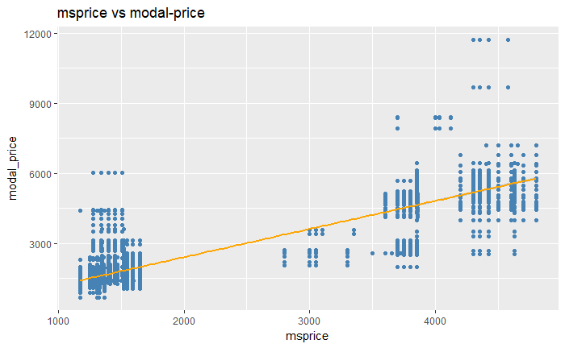

```r
ggplot(monthly_cmo_inner, aes(x=msprice, y=modal_price)) +
  geom_point(color='steelblue') +
  geom_smooth(method='lm', color='orange') +
  labs(
    y='modal_price',
    title='msprice vs modal-price')
```

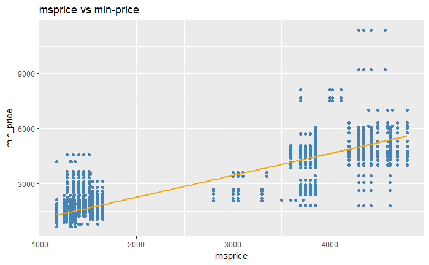

```r
ggplot(monthly_cmo_inner, aes(x=msprice, y=min_price)) +
  geom_point(color='steelblue') +
  geom_smooth(method='lm', color='orange') +
  labs(
    y='min_price',
    title='msprice vs min-price')
```

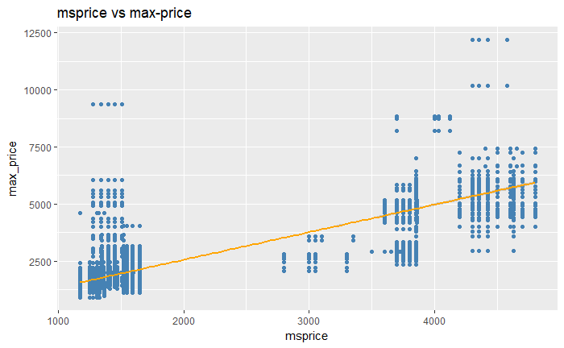

```r
ggplot(monthly_cmo_inner, aes(x=msprice, y=max_price)) +
  geom_point(color='steelblue') +
  geom_smooth(method='lm', color='orange') +
  labs(
    y='max_price',
    title='msprice vs max-price')
```

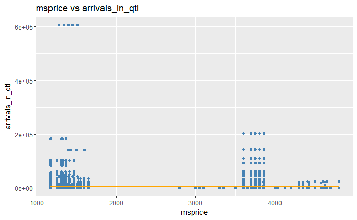

```r
ggplot(monthly_cmo_inner, aes(x=msprice, y=arrivals_in_qtl)) +
  geom_point(color='steelblue') +
  geom_smooth(method='lm', color='orange') +
  labs(
    y='arrivals_in_qtl',
    title='msprice vs arrivals_in_qtl')
```

```r
res <- cor.test(monthly_cmo_inner$msprice, monthly_cmo_inner$modal_price,
                    method = "pearson")
res
```

```
    Pearson's product-moment correlation

data:  monthly_cmo_inner$msprice and monthly_cmo_inner$modal_price
t = 123.88, df = 3951, p-value < 2.2e-16
alternative hypothesis: true correlation is not equal to 0
95 percent confidence interval:
 0.8851981 0.8979747
sample estimates:
     cor
0.891764
```

```r
res <- cor.test(monthly_cmo_inner$msprice, monthly_cmo_inner$min_price,
                    method = "pearson")
res
```

```
    Pearson's product-moment correlation

data:  monthly_cmo_inner$msprice and monthly_cmo_inner$min_price
t = 131.94, df = 3951, p-value < 2.2e-16
alternative hypothesis: true correlation is not equal to 0
95 percent confidence interval:
 0.8968483 0.9083913
sample estimates:
      cor
0.9027822
```

```r
res <- cor.test(monthly_cmo_inner$msprice, monthly_cmo_inner$max_price,
                    method = "pearson")
res
```

```
    Pearson's product-moment correlation

data:  monthly_cmo_inner$msprice and monthly_cmo_inner$max_price
t = 106.58, df = 3951, p-value < 2.2e-16
alternative hypothesis: true correlation is not equal to 0
95 percent confidence interval:
 0.8530951 0.8691966
sample estimates:
     cor
0.861362
```

```r
res <- cor.test(monthly_cmo_inner$msprice, monthly_cmo_inner$arrivals_in_qtl,
                    method = "pearson")
res
```

```
    Pearson's product-moment correlation

data:  monthly_cmo_inner$msprice and monthly_cmo_inner$arrivals_in_qtl
t = -0.25901, df = 3951, p-value = 0.7956
alternative hypothesis: true correlation is not equal to 0
95 percent confidence interval:
 -0.03529128  0.02705800
sample estimates:
         cor
-0.004120643
```

```r
k4 <- k1 %>% inner_join(k2, by = "Month")
k4 %>% inner_join(k3, by = "Month")
```

[output not shown]

| Month | Count_kharif | count_Rabi | count_other |
| --- | --- | --- | --- |
| November | 3280 | 835 | 5 |

```r
monthly_cmo_left <- as.data.table(monthly_cmo_left)
```

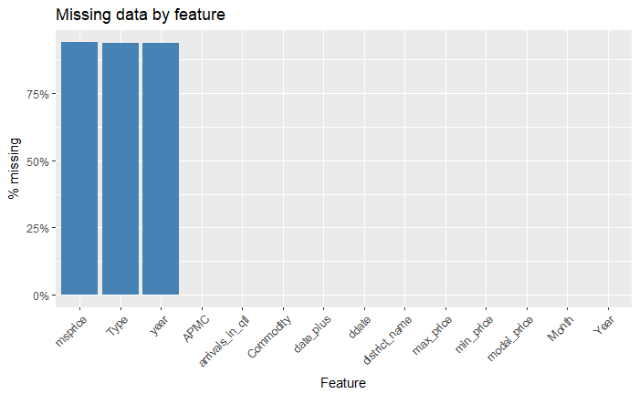

```r
data.table(
  pmiss = sapply(monthly_cmo_left, function(x) { (sum(is.na(x)) / length(x)) }),
  column = names(monthly_cmo_left)
  ) %>%
ggplot(aes(x = reorder(column, -pmiss), y = pmiss)) +
geom_bar(stat = 'identity', fill = 'steelblue') +
  scale_y_continuous(labels = scales::percent) +
  theme(axis.text.x = element_text(angle = 45, hjust = 1)) +
  labs(
    title='Missing data by feature',
    x='Feature',
    y='% missing')
```

# Only thing is sure there are a lot of commodities and APMC, and for each of them we have to do separetly build forecasting models

# I will be building forecasting models on one of the combination of APMC and Commodity

# APMC = ‘Ahmednagar’ and Commodity = ‘Bajri’

```r
monthly_trial <- monthly_cmo_left %>%
                  filter( APMC == 'Ahmednagar', Commodity == 'Bajri') %>%
                  arrange(date_plus)
```

```r
monthly_trial <- as.data.table(monthly_trial)
```

```r
str(monthly_trial)
```

```
Classes ‘data.table’ and 'data.frame':  22 obs. of  13 variables:
 $ APMC           : Factor w/ 349 levels "Aamgaon","Aarni",..: 5 5 5 5 5 5 5 5 5 5 ...
 $ Commodity      : chr  "Bajri" "Bajri" "Bajri" "Bajri" ...
 $ Year           : int  2014 2014 2015 2015 2015 2015 2015 2015 2015 2015 ...
 $ Month          : Factor w/ 12 levels "April","August",..: 12 10 5 4 8 1 7 6 2 12 ...
 $ arrivals_in_qtl: int  24 395 97 10 14 79 141 213 24 51 ...
 $ min_price      : int  1400 1507 1472 1500 1350 1406 1311 1503 1615 1438 ...
 $ max_price      : int  1750 1750 1764 1800 1700 1538 1404 1578 1615 1588 ...
 $ modal_price    : int  1575 1629 1618 1650 1525 1463 1382 1578 1615 1553 ...
 $ district_name  : Factor w/ 33 levels "Ahmadnagar","Akola",..: 1 1 1 1 1 1 1 1 1 1 ...
 $ date_plus      : Date, format: "2014-09-01" "2014-11-01" "2015-01-01" "2015-02-01" ...
 $ year           : int  NA NA NA NA NA NA NA NA NA NA ...
 $ Type           : Factor w/ 3 levels "Kharif Crops",..: NA NA NA NA NA NA NA NA NA NA ...
 $ msprice        : int  NA NA NA NA NA NA NA NA NA NA ...
 - attr(*, ".internal.selfref")=<externalptr>
```

# Lets see relationship between arrivals in qtl and modal price

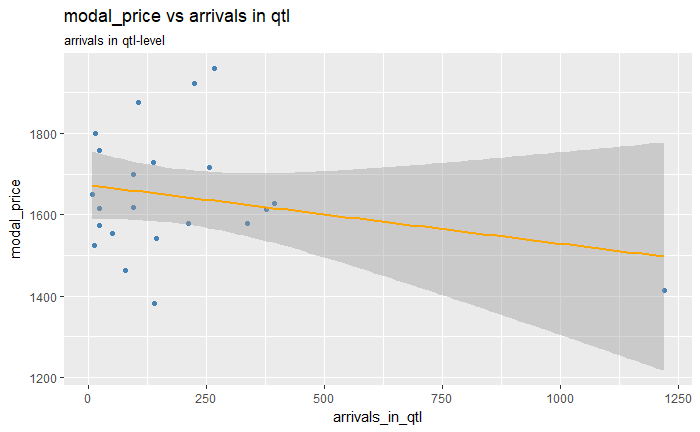

```r
ggplot(monthly_trial, aes(x=arrivals_in_qtl, y=modal_price)) +
  geom_point(color='steelblue') +
  geom_smooth(method='lm', color='orange') +
  labs(
    y='modal_price',
    title='modal_price vs arrivals in qtl',
    subtitle='arrivals in qtl-level')
```

# Lets see relationship between min price and modal price

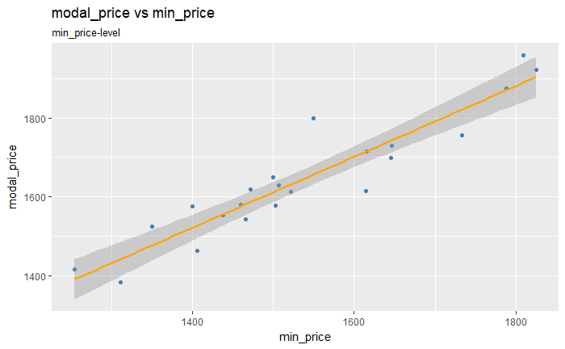

```r
ggplot(monthly_trial, aes(x=min_price, y=modal_price)) +
  geom_point(color='steelblue') +
  geom_smooth(method='lm', color='orange') +
  labs(
    y='modal_price',
    title='modal_price vs min_price',
    subtitle='min_price-level')
```

# Lets see relationship between max price and modal price

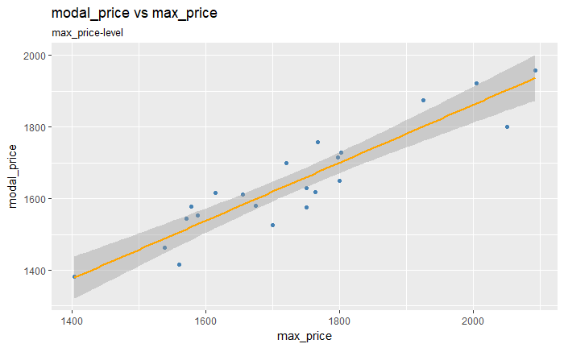

```r
ggplot(monthly_trial, aes(x=max_price, y=modal_price)) +
  geom_point(color='steelblue') +
  geom_smooth(method='lm', color='orange') +
  labs(
    y='modal_price',
    title='modal_price vs max_price',
    subtitle='max_price-level')
```

```r
res <- cor.test(monthly_trial$arrivals_in_qtl, monthly_trial$modal_price,
                    method = "pearson")
res
```

```
    Pearson's product-moment correlation

data:  monthly_trial$arrivals_in_qtl and monthly_trial$modal_price
t = -1.1328, df = 20, p-value = 0.2707
alternative hypothesis: true correlation is not equal to 0
95 percent confidence interval:
 -0.6045667  0.1963946
sample estimates:
       cor
-0.2455454
```

```r
res <- cor.test(monthly_trial$min_price, monthly_trial$modal_price,
                    method = "pearson")
res
```

```
    Pearson's product-moment correlation

data:  monthly_trial$min_price and monthly_trial$modal_price
t = 11.782, df = 20, p-value = 1.878e-10
alternative hypothesis: true correlation is not equal to 0
95 percent confidence interval:
 0.8472825 0.9729998
sample estimates:
      cor
0.9349181
```

```r
res <- cor.test(monthly_trial$max_price, monthly_trial$modal_price,
                    method = "pearson")
res
```

```
    Pearson's product-moment correlation

data:  monthly_trial$max_price and monthly_trial$modal_price
t = 10.613, df = 20, p-value = 1.152e-09
alternative hypothesis: true correlation is not equal to 0
95 percent confidence interval:
 0.8175708 0.9673141
sample estimates:
     cor
0.921532
```